# Unsupervised Learning Project

### B. Print Classification metrics for train data. [1 Marks]

```python
def ClassificationReport(model,X_train_scaled, X_test_scaled, y_train, y_test):
    #Predict the response for Training dataset
    y_train_pred = model.predict(X_train_scaled)

    #Predict the response for test dataset
    y_test_pred = model.predict(X_test_scaled)

    # Training Set
    print("Training Set")
    print(classification_report(y_train, y_train_pred))

    # confusion matrix Training Set
    cm_Test = confusion_matrix(y_train, y_train_pred, labels=[0, 1,2])
    df_cm = pd.DataFrame(cm_Test,index=[i for i in ["bus", "car","van"]],
            columns=[i for i in ["bus", "car","van"]],
        )
    plt.figure(figsize=(7, 5))
    sns.heatmap(df_cm, annot=True, fmt="g")
    plt.title("CONFUSION MATRIX : Training Data", fontsize=14)
    plt.show()

    # Test Set
    print("Test Set")
    print(classification_report(y_test, y_test_pred))

    #confusion matrix Test Set
    cm_Test = confusion_matrix(y_test, y_test_pred, labels=[0, 1,2])
    df_cm = pd.DataFrame(cm_Test,index=[i for i in ["bus", "car","van"]],
            columns=[i for i in ["bus", "car","van"]],
        )
    plt.figure(figsize=(7, 5))
    sns.heatmap(df_cm, annot=True, fmt="g")
    plt.title("CONFUSION MATRIX : Test Data", fontsize=14)
    plt.show()
```

```
Training Set
              precision    recall  f1-score   support

           0       0.94      0.96      0.95       140
           1       0.98      0.97      0.97       311
           2       0.97      0.97      0.97       141

    accuracy                           0.97       592
   macro avg       0.96      0.97      0.96       592
weighted avg       0.97      0.97      0.97       592
```

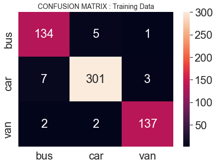

```
Test Set
              precision    recall  f1-score   support

           0       0.92      0.87      0.89        78
           1       0.93      0.94      0.93       118
           2       0.92      0.95      0.93        58

    accuracy                           0.92       254
   macro avg       0.92      0.92      0.92       254
weighted avg       0.92      0.92      0.92       254
```

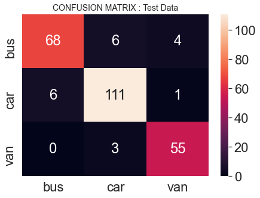

```python
ClassificationReport(clf,X_train_scaled, X_test_scaled, y_train, y_test)
```

Observation:

Training Data:

```
Total number of Type-I and Type-II errors are 20

From the classification report, it can be seen that the model has an average weighted performance of around 97%
ranging from precision, recall, f1-score, and support.
```

- IN case of 141 actual vans our svm model has correcly classified 137 vans. it has wrongly classified 2 vans to be a bus and also 2 vans to be a cars
- IN case of 311 actual cars our svm model has correcly classified 301 cars. it has wrongly classified 7 cars to be a bus and also 3 cars to be a van
- In case of 140 actual bus our svm model has correctly classified 134 buses , It has wrongly classified 1 bus to be a van and 5 buses to be a car.

Test Data:

```
Total number of Type-I and Type-II errors are 20

From the classification report, it can be seen that the model has an average weighted performance of around 92%
ranging from precision, recall, f1-score, and support.
```

- IN case of 58 actual vans our svm model has correcly classified 55 vans. it has wrongly classified 3 vans to be a cars
- IN case of 118 actual cars our svm model has correcly classified 111 cars. it has wrongly classified 6 cars to be a bus and also 1 cars to be a van
- In case of 78 actual bus our svm model has correctly classified 68 buses , It has wrongly classified 4 bus to be a van and 6 buses to be a car.

This is a good model as we have accuracy of 97% for training set and 92% for test set. </span>

### C. Apply PCA on the data with 10 components. [3 Marks]

```python
# scaling the data using the standard scaler
X_scaled = StandardScaler().fit_transform(X)
```

```python
#generating only 10 PCA dimensions
pca = PCA(n_components=10)

X_scaled_pca = pca.fit_transform(X_scaled)
X_scaled_pca.shape
```

```
(846, 10)
```

```python
pca.explained_variance_ratio_
```

```
array([0.52186034, 0.16729768, 0.10562639, 0.0654746 , 0.05089869,
       0.02996413, 0.01991366, 0.01231501, 0.00891215, 0.00509715])
```

### D. Visualize Cumulative Variance Explained with Number of Components. [2 Marks]

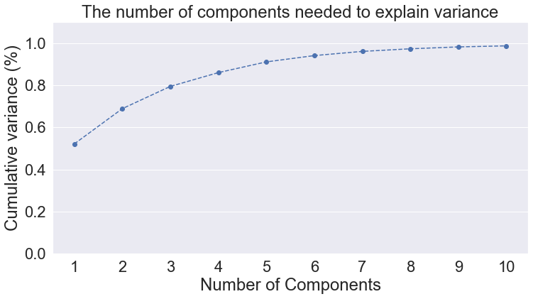

```python
# 10 PCA  : the "cumulative variance explained" analysis

plt.rcParams["figure.figsize"] = (12,6)

fig, ax = plt.subplots()
xi = np.arange(1, 11, step=1)
yi= np.cumsum(pca.explained_variance_ratio_)

plt.ylim(0.0,1.1)
plt.plot(xi, yi, marker='o', linestyle='--', color='b')

plt.xlabel('Number of Components')
plt.xticks(np.arange(1, 11, step=1))
plt.ylabel('Cumulative variance (%)')
plt.title('The number of components needed to explain variance')

ax.grid(axis='x')
plt.show()
```

### E. Draw a horizontal line on the above plot to highlight the threshold of 90%. [1 Marks]

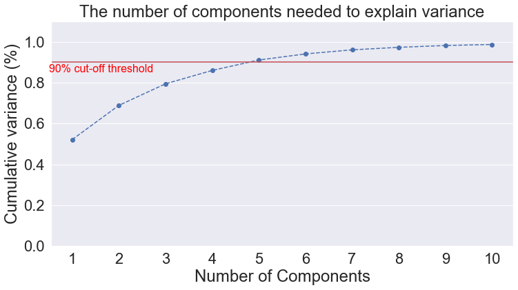

```python
# the "cumulative variance explained" analysis with threshold of 90%
plt.rcParams["figure.figsize"] = (12,6)

fig, ax = plt.subplots()
xi = np.arange(1, 11, step=1)
yi = np.cumsum(pca.explained_variance_ratio_)

plt.ylim(0.0,1.1)
plt.plot(xi, yi, marker='o', linestyle='--', color='b')

plt.xlabel('Number of Components')
plt.xticks(np.arange(1, 11, step=1))
plt.ylabel('Cumulative variance (%)')
plt.title('The number of components needed to explain variance')

plt.axhline(y=0.90, color='r', linestyle='-')
plt.text(0.5, 0.85, '90% cut-off threshold', color = 'red', fontsize=16)

ax.grid(axis='x')
plt.show()
```

### F. Apply PCA on the data. This time Select Minimum Components with 90% or above variance explained. [2 Marks]

```python
#we first need to know how many components are required to explain at least 90% of our feature variation:
pca_full = PCA(n_components=18)
X_scaled_pcafull=pca_full.fit_transform(X_scaled)
X_scaled_pcafull.shape
```

```
(846, 18)
```

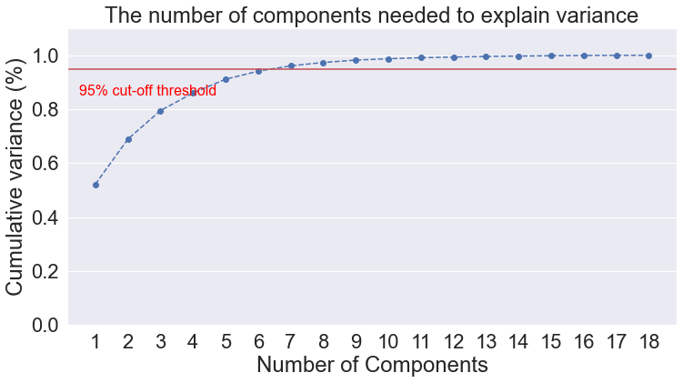

```python
# 18 Attributes :the "cumulative variance explained" analysis with threshold of 95%

plt.rcParams["figure.figsize"] = (12,6)

fig, ax = plt.subplots()
xi = np.arange(1, 19, step=1)
yi = np.cumsum(pca_full.explained_variance_ratio_)

plt.ylim(0.0,1.1)
plt.plot(xi, yi, marker='o', linestyle='--', color='b')

plt.xlabel('Number of Components')
plt.xticks(np.arange(1, 19, step=1)) #change from 0-based array index to 1-based human-readable label
plt.ylabel('Cumulative variance (%)')
plt.title('The number of components needed to explain variance')

plt.axhline(y=0.95, color='r', linestyle='-')
plt.text(0.5, 0.85, '95% cut-off threshold', color = 'red', fontsize=16)

ax.grid(axis='x')
plt.show()
```